# Tipos de variables y niveles de medición en Ciencias Sociales

Taller de Análisis Cuantitativo

Curso de Análisis Cuantitativo

2026-08-10

# 1 Presentación

Este taller ilustra los **tipos de variables estadísticas** y los **niveles de medición** (nominal, ordinal, intervalo y razón) con datos reales. La idea de fondo es que *el nivel de medición no es una propiedad del concepto sino de su operacionalización*: la manera en que decidimos medir una variable determina qué estadísticos descriptivos y qué visualizaciones son legítimos.

Usamos dos bases del experimento natural sobre la TV rusa en Ucrania. Un mismo concepto —el **apoyo pro-ruso**— aparece medido de dos formas distintas según la **unidad de análisis**:

- `UA_precincts.csv`: **precintos electorales** (unidad agregada / ecológica). El apoyo pro-ruso es un **porcentaje continuo**.
- `UA_survey.csv`: **personas encuestadas** (unidad individual). El apoyo pro-ruso es una respuesta **binaria** (votó / no votó).

> Coloca los dos `.csv` en la misma carpeta que este `.Rmd` antes de tejer.

```r
precincts <- read_csv("UA_precincts.csv")
survey    <- read_csv("UA_survey.csv")

glimpse(precincts)
```

```
## Rows: 3,589
## Columns: 4
## $ russian_tv        <dbl> 0, 0, 1, 0, 0, 1, 0, 0, 0, 0, 0, 0, 0, 0, 0, 0, 0, 0…
## $ pro_russian       <dbl> 2.7210884, 0.8928571, 1.6949153, 72.2689076, 1.28205…
## $ prior_pro_russian <dbl> 25.14286, 35.34483, 20.53232, 84.47761, 28.99408, 45…
## $ within_25km       <dbl> 1, 0, 1, 1, 0, 0, 0, 0, 0, 0, 0, 0, 0, 0, 0, 0, 0, 0…
```

```r
glimpse(survey)
```

```
## Rows: 358
## Columns: 3
## $ russian_tv       <dbl> 1, 1, 0, 0, 0, 1, 0, 0, 1, 1, 1, 1, 1, 1, 1, 1, 1, 1,…
## $ pro_russian_vote <dbl> 0, 1, 0, 0, 0, 0, 0, 0, 0, 0, 0, 0, 0, 0, 0, 0, 0, 0,…
## $ within_25km      <dbl> 1, 1, 0, 1, 1, 0, 1, 1, 1, 1, 1, 1, 1, 1, 1, 1, 1, 1,…
```

## 1.1 Etiquetado de las categorías

Las variables categóricas vienen codificadas como `0/1`. Antes de describirlas conviene convertirlas en **factores** con etiquetas legibles: esto le comunica a R que son cualitativas y no números con los que tenga sentido hacer aritmética.

```r
precincts <- precincts %>%
  mutate(
    russian_tv_f  = factor(russian_tv,  levels = c(0, 1),
                           labels = c("Sin TV rusa", "Con TV rusa")),
    within_25km_f = factor(within_25km, levels = c(0, 1),
                           labels = c("Lejos (>25 km)", "Cerca (<=25 km)"))
  )

survey <- survey %>%
  mutate(
    russian_tv_f       = factor(russian_tv, levels = c(0, 1),
                                labels = c("Sin TV rusa", "Con TV rusa")),
    within_25km_f      = factor(within_25km, levels = c(0, 1),
                                labels = c("Lejos (>25 km)", "Cerca (<=25 km)")),
    pro_russian_vote_f = factor(pro_russian_vote, levels = c(0, 1),
                                labels = c("No pro-ruso", "Pro-ruso"))
  )
```

Definimos también una función auxiliar para la **moda** (el estadístico de tendencia central propio del nivel nominal):

```r
moda <- function(x) {
  ux <- unique(x)
  ux[which.max(tabulate(match(x, ux)))]
}
```

# 2 Nivel nominal

En el nivel **nominal** las categorías solo se distinguen entre sí, sin orden ni distancia. Variables de este taller: `russian_tv`, `within_25km` (ambas bases) y `pro_russian_vote` (encuesta). Todas son **dicotómicas**.

- **Descriptivos válidos:** frecuencias absolutas y relativas, moda.
- **No válidos:** media, mediana, desviación (no hay orden ni distancia).

## 2.1 Descriptivos

```r
# Frecuencias absolutas
table(precincts$russian_tv_f)
```

```
##
## Sin TV rusa Con TV rusa
##        2892         697
```

```r
# Frecuencias relativas (proporciones)
prop.table(table(precincts$russian_tv_f)) %>% round(3)
```

```
##
## Sin TV rusa Con TV rusa
##       0.806       0.194
```

```r
# Moda
moda(precincts$russian_tv_f)
```

```
## [1] Sin TV rusa
## Levels: Sin TV rusa Con TV rusa
```

Una tabla de frecuencias ordenada, útil para presentar:

```r
precincts %>%
  count(russian_tv_f, name = "frecuencia") %>%
  mutate(proporcion = round(frecuencia / sum(frecuencia), 3)) %>%
  kable()
```

| russian_tv_f | frecuencia | proporcion |
| --- | --- | --- |
| Sin TV rusa | 2892 | 0.806 |
| Con TV rusa | 697 | 0.194 |

## 2.2 Visualización

El gráfico natural para una variable nominal es el **diagrama de barras**: la altura representa un conteo o una proporción, y las barras están *separadas* porque las categorías son discretas.

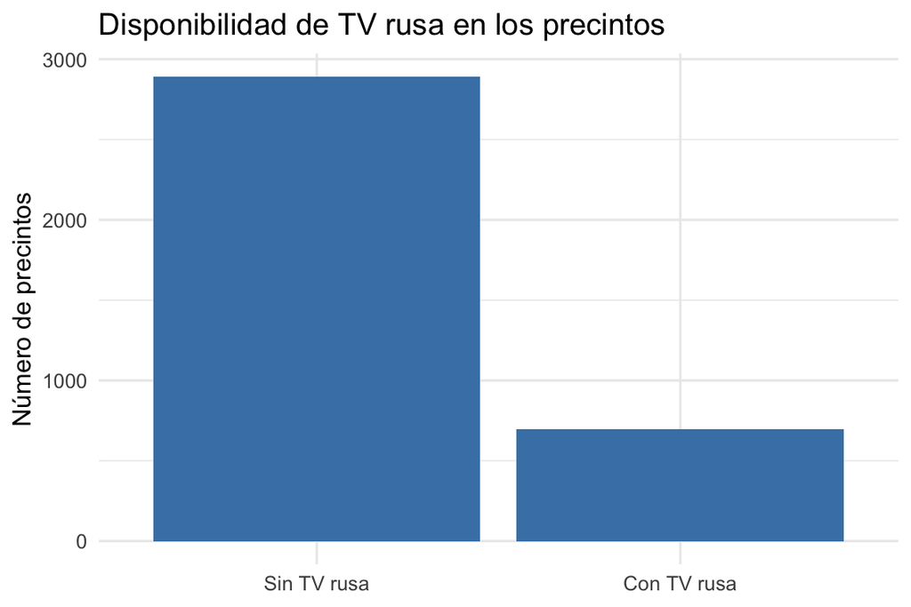

```r
ggplot(precincts, aes(x = russian_tv_f)) +
  geom_bar(fill = "steelblue") +
  labs(title = "Disponibilidad de TV rusa en los precintos",
       x = NULL, y = "Número de precintos")
```

Con dos categorías cruzadas podemos comparar composición:

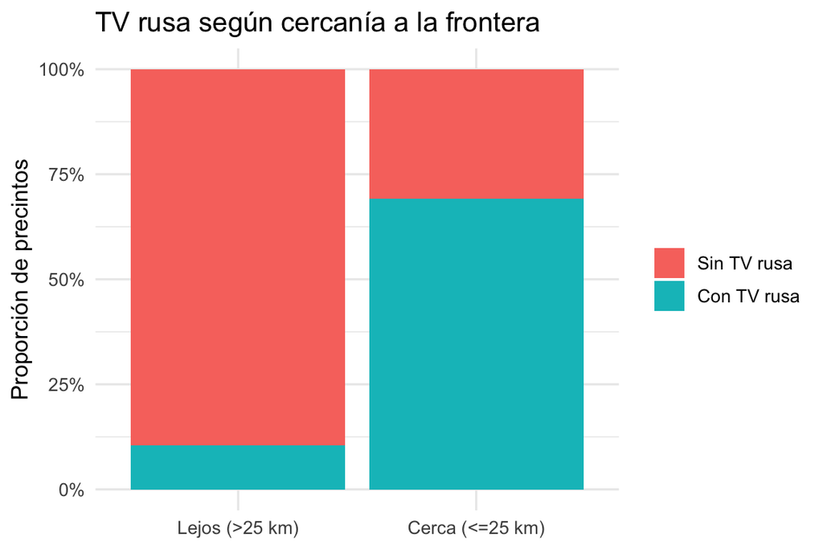

```r
ggplot(precincts, aes(x = within_25km_f, fill = russian_tv_f)) +
  geom_bar(position = "fill") +
  scale_y_continuous(labels = scales::percent) +
  labs(title = "TV rusa según cercanía a la frontera",
       x = NULL, y = "Proporción de precintos", fill = NULL)
```

# 3 Nivel ordinal

En el nivel **ordinal** las categorías tienen un **orden**, pero las distancias entre ellas no son interpretables. Los datos no traen una variable ordinal nativa, así que construimos una **discretizando** el porcentaje de voto pro-ruso en tres tramos (terciles): `Bajo`, `Medio`, `Alto`. Es un buen momento para discutir con el grupo qué se *gana* (interpretabilidad) y qué se *pierde* (información) al degradar una variable continua a ordinal.

```r
precincts <- precincts %>%
  mutate(pro_russian_cat = cut(
    pro_russian,
    breaks = quantile(pro_russian, probs = seq(0, 1, by = 1/3)),
    labels = c("Bajo", "Medio", "Alto"),
    include.lowest = TRUE,
    ordered_result = TRUE
  ))

levels(precincts$pro_russian_cat)
```

```
## [1] "Bajo"  "Medio" "Alto"
```

## 3.1 Descriptivos

- **Válidos:** frecuencias, **mediana** y cuartiles, moda.
- **No válido:** la media (no hay distancias iguales entre categorías).

```r
# Frecuencias por categoría (respetando el orden)
table(precincts$pro_russian_cat)
```

```
##
##  Bajo Medio  Alto
##  1197  1197  1195
```

```r
# Mediana ordinal: categoría que ocupa la posición central
niveles <- levels(precincts$pro_russian_cat)
niveles[round(median(as.integer(precincts$pro_russian_cat)))]
```

```
## [1] "Medio"
```

## 3.2 Visualización

Barras **ordenadas** según la secuencia de las categorías:

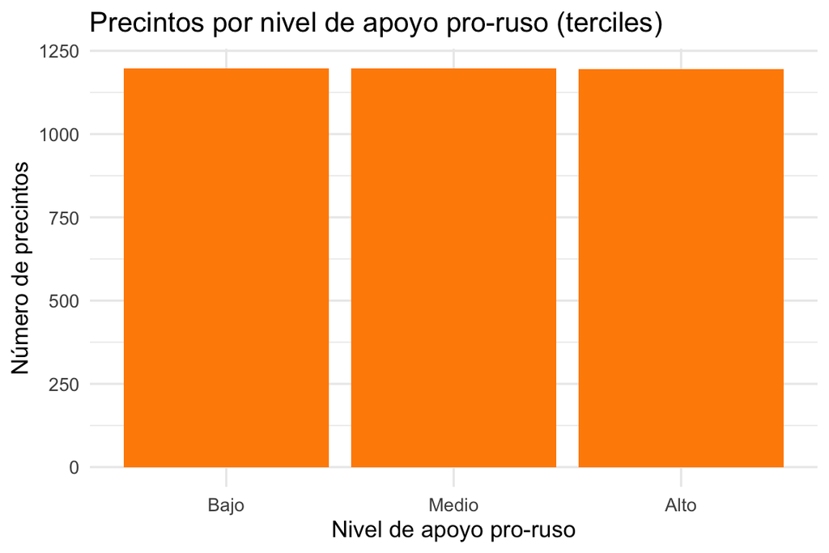

```r
ggplot(precincts, aes(x = pro_russian_cat)) +
  geom_bar(fill = "darkorange") +
  labs(title = "Precintos por nivel de apoyo pro-ruso (terciles)",
       x = "Nivel de apoyo pro-ruso", y = "Número de precintos")
```

# 4 Nivel de intervalo y de razón

Las variables `pro_russian` y `prior_pro_russian` son **cuantitativas continuas**. Como son **porcentajes con cero absoluto** (0% significa ausencia real de voto pro-ruso) y los cocientes tienen sentido (40% es el doble de 20%), están en el nivel de **razón**. La diferencia con el nivel de intervalo es justamente ese cero absoluto: en una escala de intervalo (p. ej. temperatura en °C) el cero es convencional y las razones no son interpretables.

## 4.1 Descriptivos

Aquí sí valen **todos** los estadísticos: media, mediana, desviación estándar, rango, cuartiles.

```r
summary(precincts$pro_russian)
```

```
##    Min. 1st Qu.  Median    Mean 3rd Qu.    Max.
##   0.000   8.839  21.963  26.717  45.135  78.902
```

```r
precincts %>%
  summarise(
    media    = mean(pro_russian),
    mediana  = median(pro_russian),
    desv_est = sd(pro_russian),
    minimo   = min(pro_russian),
    maximo   = max(pro_russian),
    RIC      = IQR(pro_russian)
  ) %>%
  kable(digits = 2, caption = "Apoyo pro-ruso (% de voto) por precinto")
```

Apoyo pro-ruso (% de voto) por precinto

| media | mediana | desv_est | minimo | maximo | RIC |
| --- | --- | --- | --- | --- | --- |
| 26.72 | 21.96 | 19.01 | 0 | 78.9 | 36.3 |

## 4.2 Visualización

El **histograma** muestra la forma de la distribución de una variable continua (barras *pegadas*, a diferencia del diagrama de barras nominal):

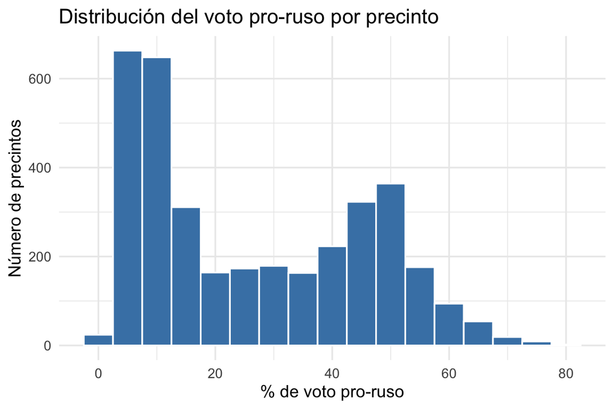

```r
ggplot(precincts, aes(x = pro_russian)) +
  geom_histogram(binwidth = 5, fill = "steelblue", color = "white") +
  labs(title = "Distribución del voto pro-ruso por precinto",
       x = "% de voto pro-ruso", y = "Número de precintos")
```

El **diagrama de caja** resume mediana, cuartiles y valores atípicos:

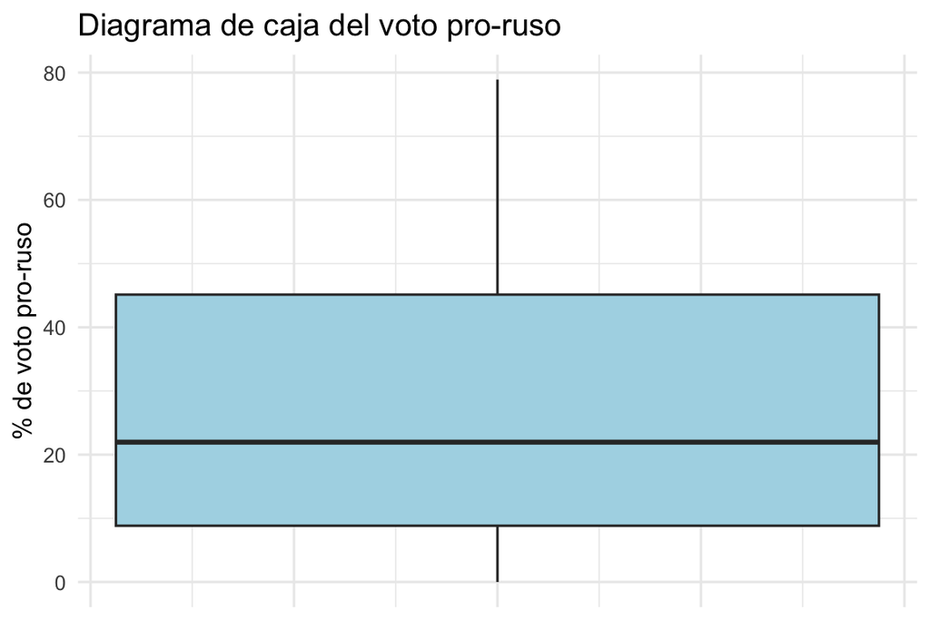

```r
ggplot(precincts, aes(y = pro_russian)) +
  geom_boxplot(fill = "lightblue") +
  labs(title = "Diagrama de caja del voto pro-ruso",
       y = "% de voto pro-ruso", x = NULL) +
  theme(axis.text.x = element_blank())
```

Con dos variables de razón podemos usar un **diagrama de dispersión** para ver su relación (voto previo vs. voto actual):

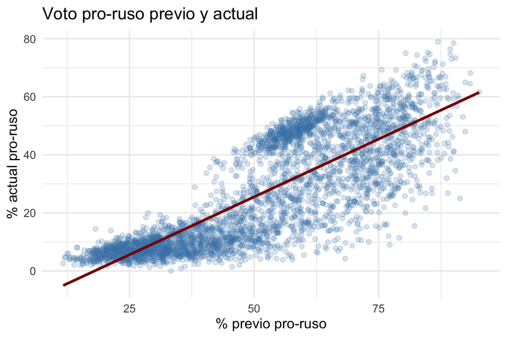

```r
ggplot(precincts, aes(x = prior_pro_russian, y = pro_russian)) +
  geom_point(alpha = 0.2, color = "steelblue") +
  geom_smooth(method = "lm", se = FALSE, color = "darkred") +
  labs(title = "Voto pro-ruso previo y actual",
       x = "% previo pro-ruso", y = "% actual pro-ruso")
```

# 5 El mismo concepto, dos niveles de medición

Este es el punto central del taller. El **apoyo pro-ruso** se operacionaliza de dos maneras según la unidad de análisis, y cada operacionalización obliga a un tratamiento estadístico distinto.

## 5.1 A nivel de precinto: variable de razón

A nivel agregado el apoyo es un **porcentaje**; lo resumimos con **medias** por grupo y lo visualizamos con **cajas**.

```r
precincts %>%
  group_by(russian_tv_f) %>%
  summarise(media_pro_russian = mean(pro_russian),
            desv = sd(pro_russian)) %>%
  kable(digits = 2)
```

| russian_tv_f | media_pro_russian | desv |
| --- | --- | --- |
| Sin TV rusa | 23.68 | 18.45 |
| Con TV rusa | 39.32 | 15.88 |

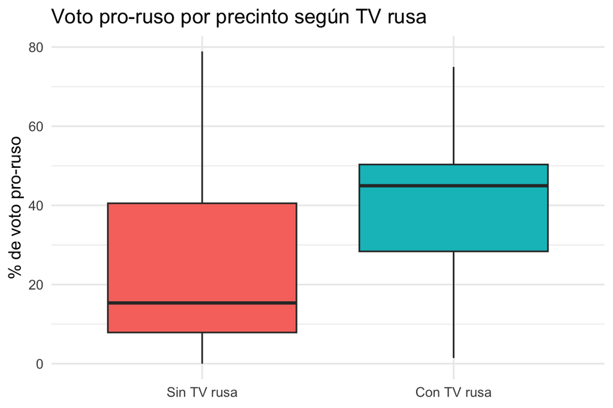

```r
ggplot(precincts, aes(x = russian_tv_f, y = pro_russian, fill = russian_tv_f)) +
  geom_boxplot(show.legend = FALSE) +
  labs(title = "Voto pro-ruso por precinto según TV rusa",
       x = NULL, y = "% de voto pro-ruso")
```

## 5.2 A nivel individual: variable nominal

A nivel individual el apoyo es **binario**. Un detalle instructivo: cuando una variable dicotómica se codifica `0/1`, **su media es la proporción** de casos con valor 1. Por eso podemos “promediar” `pro_russian_vote` sin violar su naturaleza nominal: no estamos midiendo una cantidad, sino estimando una frecuencia relativa.

```r
survey %>%
  group_by(russian_tv_f) %>%
  summarise(prop_pro_russian = mean(pro_russian_vote)) %>%
  kable(digits = 3)
```

| russian_tv_f | prop_pro_russian |
| --- | --- |
| Sin TV rusa | 0.171 |
| Con TV rusa | 0.290 |

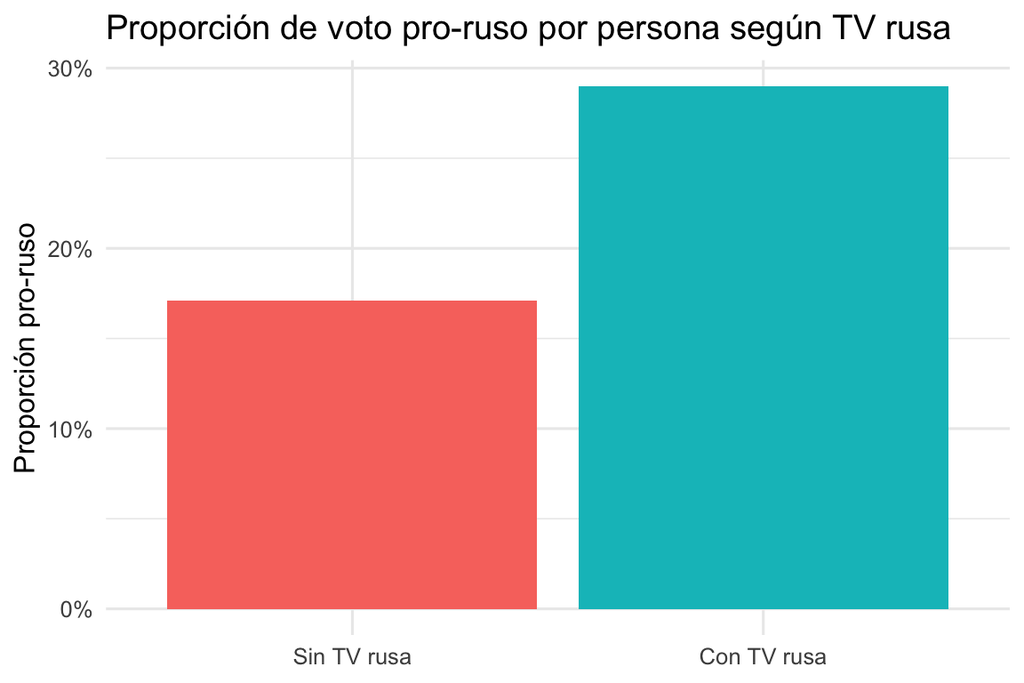

```r
survey %>%
  group_by(russian_tv_f) %>%
  summarise(prop_pro_russian = mean(pro_russian_vote)) %>%
  ggplot(aes(x = russian_tv_f, y = prop_pro_russian, fill = russian_tv_f)) +
  geom_col(show.legend = FALSE) +
  scale_y_continuous(labels = scales::percent) +
  labs(title = "Proporción de voto pro-ruso por persona según TV rusa",
       x = NULL, y = "Proporción pro-ruso")
```

## 5.3 Nota: la falacia ecológica

Tener las dos unidades permite advertir sobre la **falacia ecológica**: una correlación observada a nivel de precinto (entre exposición a TV rusa y % de voto) **no autoriza** a inferir la conducta de los individuos. Precisamente por eso el estudio original triangula el nivel agregado con el nivel individual, en vez de deducir uno del otro.

# 6 Síntesis

| Nivel | Ejemplo en los datos | Descriptivos apropiados | Visualización típica |
| --- | --- | --- | --- |
| Nominal | `russian_tv`, `pro_russian_vote` | frecuencias, proporciones, moda | barras separadas |
| Ordinal | `pro_russian_cat` (terciles) | frecuencias, mediana, cuartiles | barras ordenadas |
| Intervalo | (temperatura °C, año) | + media, desviación | histograma, caja |
| Razón | `pro_russian`, `prior_pro_russian` | + razones y coeficientes | histograma, caja, dispersión |

La regla práctica: cada nivel *hereda* los estadísticos de los niveles anteriores y **añade** los suyos. Elegir un estadístico o un gráfico que el nivel de medición no soporta (una media de una variable nominal, por ejemplo) es uno de los errores más frecuentes —y más instructivos— para discutir en clase.